# Prediction With Linear Regression

POLS 602  
Fall 2026

Mike Burnham

Texas A&M University

## Review

1. You have a bunch of data. The only thing you know about the data is that the mean of your sample is 50. An observation from the sample is chosen at random and you have to guess its value. What is your best guess?
2. You have a bunch of data. The only thing you know about the data is that the mean of your sample is 50 and the median is 60. An observation from the sample is chosen at random and you have to guess its value. What is your best guess?
3. In plain English, what is the standard deviation?
4. In plain English, what is $Z$ in this formula? $Z = \frac{x - \mu}{\sigma}$
5. Why would we want to use units of standard deviations to communicate how far something is from the mean?

## Review

Population version:
$$Z = \frac{x - \mu}{\sigma}$$

Sample version, for observation $i$ of variable $X$:
$$Z_i^X = \frac{X_i - \bar{X}}{sd(X)}$$

# Predictive Modeling

## Why Predictive Modeling

- Uncover new causal mechanisms and generate new hypotheses
- Discover new measures and compare different operationalizations
- Improvement to existing explanatory models
- Assessing the distance between theory and practice
- Compare competing theories
- Quantifying the level of predictability of measurable phenomena by creating benchmarks

Source:

*To Explain or to Predict?* Galit Shmueli, 2010

*What Can We Learn from Predictive Modeling?* Cranmer and Desmarais, 2017

## Notation and Vocabulary

- **X**: Predictors, features
- **Y**: Outcomes, observed outcomes
- **Model**: a mathematical expression that represents a relationship between data
- **Data Generating Process**: The mechanisms or processes in the real world that produce the data we observe

## Models Simplify Reality

[figure not shown]

## Models Simplify Reality

[figure not shown]

## Models Simplify Reality

[figure not shown]

## A Line Can Be a Model, Too

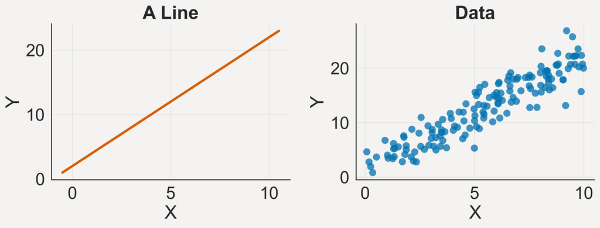

## Evaluating Models

*“…theory cannot be tested by comparing its ‘assumptions’ directly with ‘reality.’ Indeed, there is no meaningful way in which this can be done. Complete ‘realism’ is clearly unattainable, and the question whether a theory is realistic ‘enough’ can be settled only by seeing whether it yields predictions that are good enough for the purpose in hand or that are better than predictions from alternative theories. Yet the belief that a theory can be tested by the realism of its assumptions independently of the accuracy of its predictions is widespread and the source of much of the perennial criticism of economic theory as unrealistic.”*

Milton Friedman, The Methodology of Positive Economics

# Linear Regression

## The Equation of a Line

$$y = mx + b$$

Equation of a line in slope-intercept form.

## The Equation of a Line

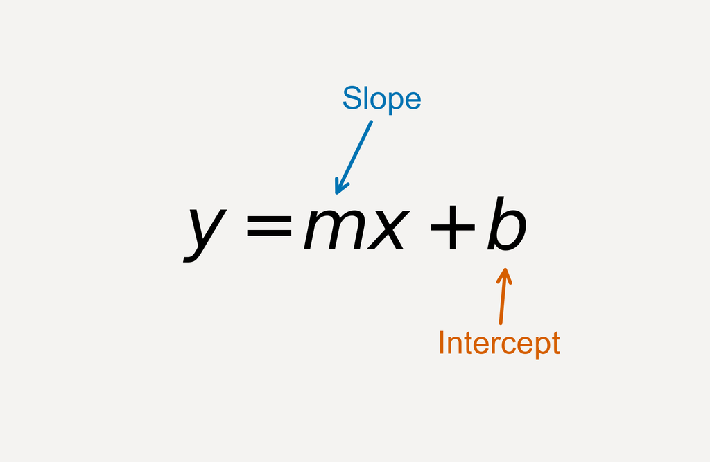

## The Equation of a Line

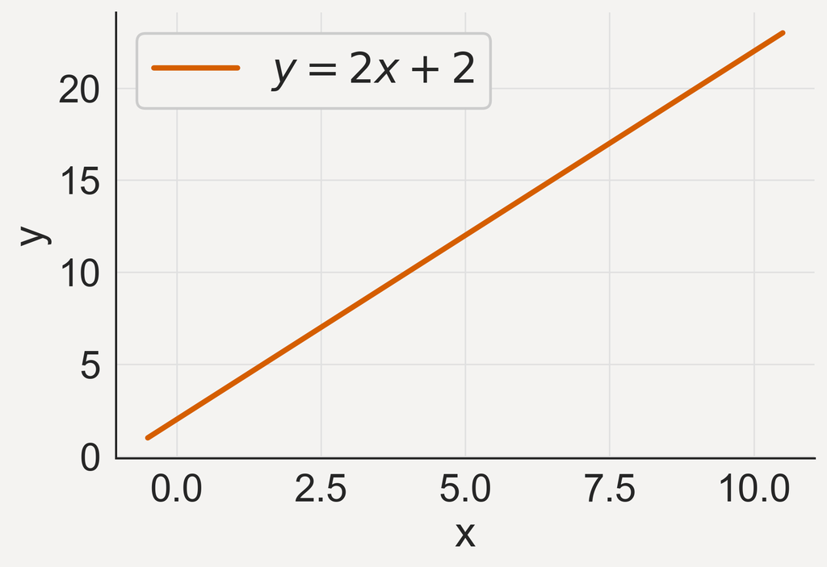

## What Does the Line Represent?

## Estimated Values

$$\widehat{Y}_i = \widehat{\alpha} + \widehat{\beta}X_i$$

$$\widehat{Y}_i = \widehat{\beta}_0 + \widehat{\beta}_1 X_i$$

- $\widehat{Y}$: Predicted values, predicted outcomes, fitted values. The values of $Y$ predicted by a model.
- $\widehat{\alpha}$: The intercept
- $\widehat{\beta}$: The slope coefficient

## Estimated Values, in Matrix Form

For all $n$ observations at once:

$$\widehat{\mathbf{Y}} = \mathbf{X}\widehat{\boldsymbol{\beta}}$$

where

$$\widehat{\mathbf{Y}} = \begin{pmatrix} \widehat{Y}_1 \\ \vdots \\ \widehat{Y}_n \end{pmatrix}, \quad
\mathbf{X} = \begin{pmatrix} 1 & X_1 \\ \vdots & \vdots \\ 1 & X_n \end{pmatrix}, \quad
\widehat{\boldsymbol{\beta}} = \begin{pmatrix} \widehat{\alpha} \\ \widehat{\beta} \end{pmatrix}$$

## Estimated Values, in Matrix Form

Set up the multiplication:

- $\mathbf{X}$ is *n by 2*
- $\widehat{\boldsymbol{\beta}}$ is *2 by 1*

$$\mathbf{X}\widehat{\boldsymbol{\beta}} =
\begin{pmatrix}
1 & X_1 \\
1 & X_2 \\
\vdots & \vdots \\
1 & X_n
\end{pmatrix}
\begin{pmatrix}
\widehat{\alpha} \\
\widehat{\beta}
\end{pmatrix}$$

## Estimated Values, in Matrix Form

Multiply each row of $\mathbf{X}$ against the coefficient vector:

$$\mathbf{X}\widehat{\boldsymbol{\beta}} =
\begin{pmatrix}
(1)(\widehat{\alpha}) + (X_1)(\widehat{\beta}) \\
(1)(\widehat{\alpha}) + (X_2)(\widehat{\beta}) \\
\vdots \\
(1)(\widehat{\alpha}) + (X_n)(\widehat{\beta})
\end{pmatrix}$$

## Estimated Values, in Matrix Form

Each entry simplifies to the scalar formula from a few slides back:

$$\mathbf{X}\widehat{\boldsymbol{\beta}} =
\begin{pmatrix}
\widehat{\alpha} + \widehat{\beta}X_1 \\
\widehat{\alpha} + \widehat{\beta}X_2 \\
\vdots \\
\widehat{\alpha} + \widehat{\beta}X_n
\end{pmatrix}
=
\widehat{\mathbf{Y}}$$

Every row of that vector is exactly $\widehat{Y}_i$.

## Estimated Values

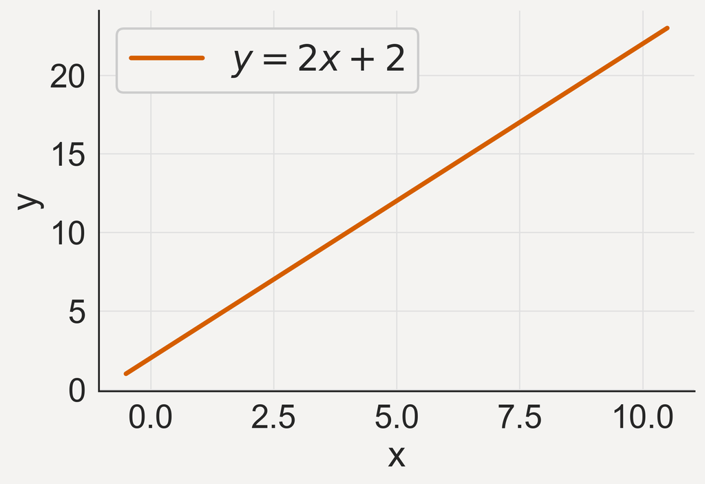

$$\widehat{Y}_i = 2 + 2X_i$$

## The Linear Regression Model

$$Y_i = \alpha + \beta X_i + \epsilon_i$$

- Notice no hats! This is the true, unobserved relationship — not an estimate.
- The new term $\epsilon_i$ is the prediction error, the error term, or the residual.
- $\epsilon_i = Y_i - \widehat{Y}_i$

## The Linear Regression Model, in Matrix Form

$$\mathbf{Y} = \mathbf{X}\boldsymbol{\beta} + \boldsymbol{\varepsilon}$$

where $\mathbf{Y}$ and $\boldsymbol{\varepsilon}$ are $n \times 1$ vectors, $\mathbf{X}$ is the $n \times 2$ design matrix from a few slides back, and $\boldsymbol{\beta} = (\alpha, \beta)^\top$.

$$\boldsymbol{\varepsilon} = \mathbf{Y} - \mathbf{X}\boldsymbol{\beta}$$

## Example: Social Pressure and Turnout

- Recall the Gerber, Green, and Larimer (2008) field experiment
- $Y_i$ — `voted` — did the person vote? ($1$ = yes, $0$ = no)
- $X_i$ — `treatment` — did the person receive the “Neighbors” social pressure mailer? ($1$ = yes, $0$ = no)
- Last time: compare group means directly. Today: run this as a regression.

We want to estimate $P(Y \mid X)$ — the probability of voting, conditional on treatment status.

## Estimating the Effect: Difference in Means

For a binary outcome, the conditional probability of $Y$ given $X$ is just the sample mean of $Y$ within that group:

$$P(Y_i \mid X_i = x) = \bar{Y}_x = \frac{1}{n_x} \sum_{i:\, X_i = x} Y_i$$

Recall the difference-in-means estimator:

$$\widehat{\text{average_causal_effect}} = \bar{Y}_{\text{treatment_group}} - \bar{Y}_{\text{control_group}}$$

Calculate each group’s mean turnout rate:

$$\bar{Y}_{\text{control}} = 0.30 \qquad \bar{Y}_{\text{treatment}} = 0.38$$

$$\widehat{\text{average_causal_effect}} = 0.38 - 0.30 = 0.08$$

## Regressing Turnout on Treatment

$$P(\text{voted}_i \mid \text{treatment}_i) = \alpha + \beta \, \text{treatment}_i$$

alternatively, if we add the error term we get $\text{voted}_i$ as the dependent variable:

$$\text{voted}_i = \alpha + \beta \, \text{treatment}_i + \epsilon_i$$

## Solving for the control group

$$P(\text{voted}_i \mid \text{treatment}_i) = \alpha + \beta \, \text{treatment}_i$$

For everyone in the control group, $\text{treatment}_i = 0$:

$$P(\text{voted}_i \mid \text{treatment}_i = 0) = \alpha + \beta (0)$$

The $\beta$ term vanishes:

$$P(\text{voted}_i \mid \text{treatment}_i = 0) = \alpha$$

## Solving for $\alpha$

$$P(\text{voted}_i \mid \text{treatment}_i = 0) = \alpha$$

We estimate a conditional probability for a binary outcome the same way we estimate any probability: as a sample proportion — the mean of $\text{voted}_i$ among control-group observations.

$$\widehat{P}(\text{voted}_i \mid \text{treatment}_i = 0) = \bar{Y}_{\text{control}}$$

$$\boxed{\alpha = \bar{Y}_{\text{control}}} \;=\; 0.30$$

## Solving for $\beta$: Set $X_i = 1$

$$P(\text{voted}_i \mid \text{treatment}_i = 1) = \alpha + \beta (1) = \alpha + \beta$$

Estimate this conditional probability the same way, now using the treatment group’s sample mean:

$$\widehat{P}(\text{voted}_i \mid \text{treatment}_i = 1) = \bar{Y}_{\text{treatment}} = \alpha + \beta$$

Plug in $\alpha = 0.30$ and solve for $\beta$:

$$\beta = \bar{Y}_{\text{treatment}} - \alpha$$

$$\beta = 0.38 - 0.30 = 0.08$$

## $\beta$ As the Difference-in-Means Estimator

Since $\alpha = \bar{Y}_{\text{control}}$,

$$\beta = \bar{Y}_{\text{treatment}} - \alpha$$

is the same as

$$\beta = \bar{Y}_{\text{treatment}} - \bar{Y}_{\text{control}}$$

This is **exactly** the difference-in-means estimator:

$$\widehat{\text{average_causal_effect}} = \bar{Y}_{\text{treatment_group}} - \bar{Y}_{\text{control_group}}$$

$\beta = 0.38 - 0.30 = 0.08$ — receiving the social pressure message is associated with an 8 percentage point increase in turnout.

## Estimand, Estimator, Estimate

[figure not shown]

## Regression as an Estimator

# Regression Errors

## Regression Errors

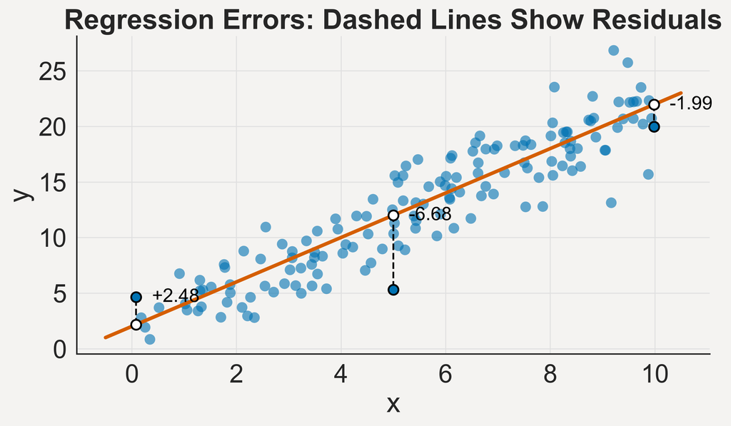

## The True Relationship

$$Y_i = \alpha + \beta X_i + \epsilon_i$$

## From True to Estimated

$$\widehat{Y}_i = \widehat{\alpha} + \widehat{\beta} X_i$$

## Regression Errors

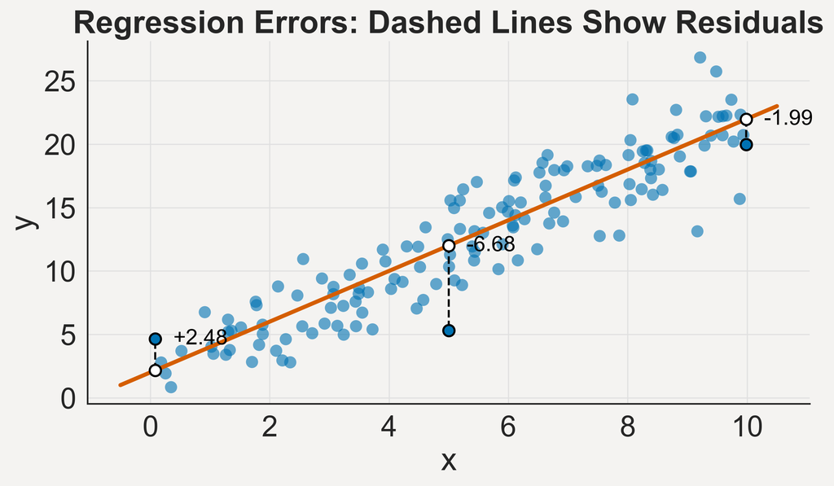

## Regression Errors

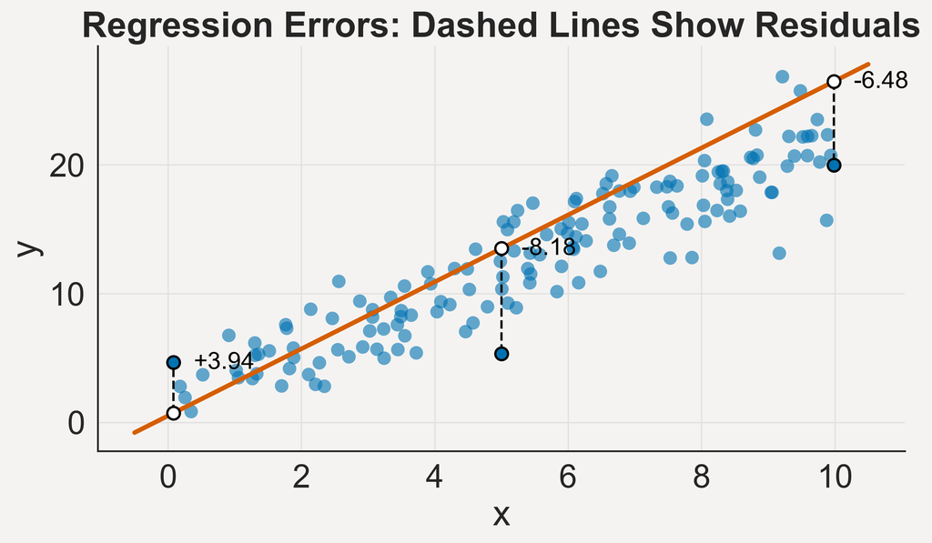

## Regression Errors

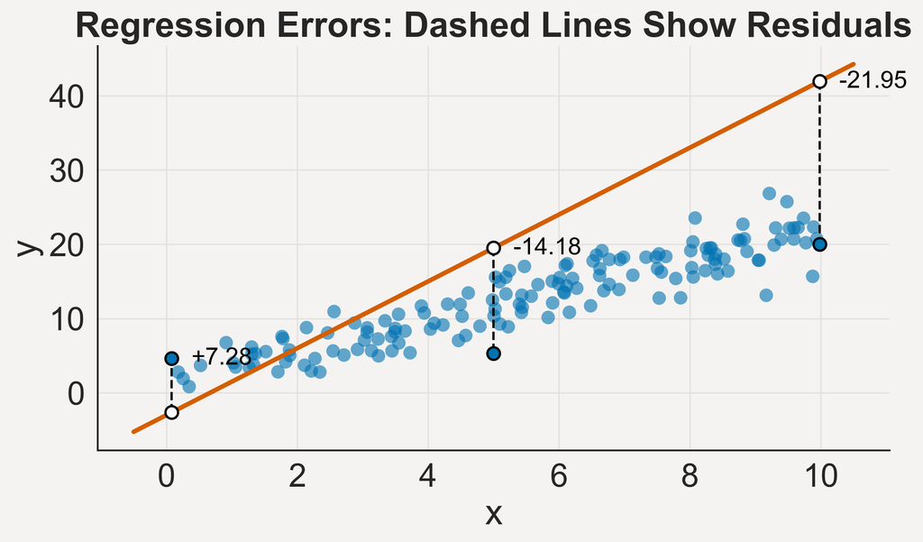

## Regression Errors

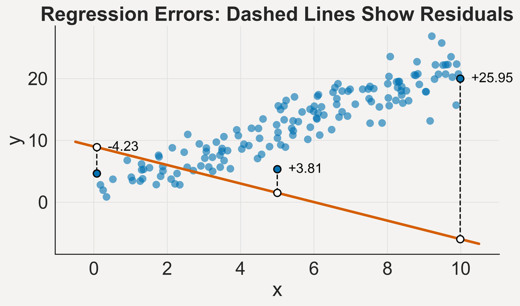

## Measuring Fit: Sum of Squared Errors

$$SSE = \sum_{i=1}^n \widehat{\epsilon}_i^2 = \sum_{i=1}^n (Y_i - \widehat{Y}_i)^2$$

In matrix/vector form:

$$SSE = \widehat{\boldsymbol{\varepsilon}}^\top \widehat{\boldsymbol{\varepsilon}} = \lVert \widehat{\boldsymbol{\varepsilon}} \rVert_2^2$$

## Measuring Fit: Sum of Squared Errors

Set up the multiplication: $\widehat{\boldsymbol{\varepsilon}}^\top$ is *1 by n*, $\widehat{\boldsymbol{\varepsilon}}$ is *n by 1*.

$$\widehat{\boldsymbol{\varepsilon}}^\top \widehat{\boldsymbol{\varepsilon}} =
\begin{pmatrix} \widehat{\epsilon}_1 & \widehat{\epsilon}_2 & \cdots & \widehat{\epsilon}_n \end{pmatrix}
\begin{pmatrix} \widehat{\epsilon}_1 \\ \widehat{\epsilon}_2 \\ \vdots \\ \widehat{\epsilon}_n \end{pmatrix}$$

## Measuring Fit: Sum of Squared Errors

Multiply matching positions, then add — the dot product:

$$\begin{aligned}
\widehat{\boldsymbol{\varepsilon}}^\top \widehat{\boldsymbol{\varepsilon}} &=
(\widehat{\epsilon}_1)(\widehat{\epsilon}_1) + (\widehat{\epsilon}_2)(\widehat{\epsilon}_2) \\
&\quad + \cdots + (\widehat{\epsilon}_n)(\widehat{\epsilon}_n)
\end{aligned}$$

## Measuring Fit: Sum of Squared Errors

Each term is a residual times itself — a square:

$$\begin{aligned}
\widehat{\boldsymbol{\varepsilon}}^\top \widehat{\boldsymbol{\varepsilon}} &=
\widehat{\epsilon}_1^2 + \widehat{\epsilon}_2^2 + \cdots + \widehat{\epsilon}_n^2 \\
&= \sum_{i=1}^n \widehat{\epsilon}_i^2 = SSE
\end{aligned}$$